# Diaspara life history trait models

DIASPARA work package 2.2

Author

Viktor Thunell, Jan Dag Pohlmann, Rebecca Whitlock

Published

27-01-2026

# DIASPARA Work package 2.2 - Life history trait models

## Introduction

We use hierarchical Bayesian models for building LHT models due the framework’s flexibility in tailoring process models, estimate uncertainty across hierarchical levels, share information across spatiotemporal scales to improve estimates in of data poor areas and infer large scale processes from smaller scales, and make use of prior information to improve estimates of biological processes.

The current analysis comprise two LHT:s (and models) for each species: Yellow eel growth / length at age, eel length at silvering, salmon growth / length at age and salmon fecundity. The choice of LHTs are based on management needs and availability of data.

## Eel

### Spatial variation in yellow eel length at age

To describe spatial variation in individual body length as a function of age, we used the Schnute growth function (Schnute 1981). This is based on the principle of growth acceleration and is an umbrella formulation of common growth functions (e.g. the von Bertalanffy and Gompertz growth functions) allowing flexibility in growth curvature. This is suitable for eel as it displays large variation in length at age between the sexes and throughout its distribution area.

In this model, we estimate spatial correlation between the Schnute parameters across eco-regions. We account for this correlation between the parameters in the Schnute growth equation at nested spatial scales having them vary through river basin specific estimates nested in eco-regions.

#### Data

Region specific temperature information from the HydroSHEDS database (Lehner, Verdin, and Jarvis 2008) was retrieved using the the DIASPARA habitat database (DIASPARA WP3) and was z-score scaled before use in the model.

#### Model description

We modeled individual yellow eel age dependent length (growth) trajectories using the Schnute growth equation (Schnute 1981). We let the parameters of the growth equation vary by sex, environmental temperature, habitat type and river basin. River basins $(j = 1,\dots,n_{j})$ are nested within eco-regions $(r = 1,\dots,n_{r})$ (hereafter regions) and we assess the spatial correlation of the Schnute-parameters across regions.

Observed length $L_i$ of individual $i$ is modeled using a normal likelihood:

$L_i \sim \text{Normal}(\mu_{L_i}, \sigma_L)$

where the expected length $\mu_i$ is defined by the Schnute growth function:

$\mu_{L_i} = \Bigg(L1_i^{p_i} + (L2_i^{p_i} - L1_i^{p_i}) \frac{1 - \exp(-k_i (age_i - A1))}{1 - \exp(-k_i (A2 - A1))} \Bigg)^{1/p_i}$

where $A1$ and $A2$ are reference ages (in our case the minimum and maximum ages in the population) defined prior to estimation, $L1$ and $L2$ the estimated lengths at $A1$ and $A2$, $p$ a shape parameter controlling curvature and $k$ is the growth coefficient.

All four Schnute parameters are estimated at the river basin level. Covariate effects of temperature $b_t$ (for $L2$ and $k_i$), sex $b_s$ ($L2$ and $k_i$) and habitat $b_h$ (for $k_i$) are additive. Missing individual sex observations are estimated by treating sex as a Bernoulli distributed random variable with probability $p_s$ (assigned to males).

Basin-specific mean Schnute parameter $par$ estimates $\mu_{par,j}$ ($n = n_b * n_par = 488$) were drawn from normal distributions with eco-region specific parameter means $\mu_{par,r}$ and standard deviations $sd_{p,r}$ ($n= n_r * n_par = 40$).

$${\mu_{par,j}} \sim \text{Normal}(\boldsymbol{\mu_{par,r}}, \boldsymbol{\sigma_{par,r}})$$
In turn, $\mu_{par,r}$ are drawn from a multivariate distribution of with a mean vector $\mu_{par}$ and covariance matrix $\Sigma_{par}$

$$\boldsymbol{\mu_{par,r}} \sim \text{MVN}(\boldsymbol{\mu_par}, \Sigma_{par}),$$
which is estimated using an LKJ prior on the correlation matrix of $\Sigma_{par}$ and
$$\Sigma_{par} = D R_{par} D,$$

where $D$ is a diagonal matrix of region specific standard deviations $\sigma_{par}$. Global hyperparameters $\mu_{par}$ define the mean growth parameters for each region, while $\sigma_{par}$ defines region level variation (see Table 1).

We chose weakly informative priors and used available literature values for asymptotic lengths $L1$ and growth coefficient $k$ from Fishbase (Froese, R. and Pauly, D. 2025).

The model was implemented in NIMBLE, and posterior distributions of model parameters was estimated using Hamiltonian Monte Carlo sampling. Convergence was assessed by checking trace plots and Gelman–Rubin diagnostics (Gelman and Rubin 1992) (see model scripts and summary for details on model formulation and diagnostics).

Table 1: Prior distributions for parameters in the eel length at age model.(**Values for $L1$, $L2$ and $k$ are estimated on log scale and are lognormal transformations of estimates from Fishbase (Froese, R. and Pauly, D. 2025)*.

| Parameter | Description | Prior distribution | Values |
| --- | --- | --- | --- |
| $\sigma_L$ | Observation-level SD of length | $\text{Exponential}(0.01)$ |  |
| $\boldsymbol{\mu_{par,j}}$ | Basin specific growth parameters | $\text{Normal}(\mu_{par,r}, sd_{p,r})$ |  |
| $\boldsymbol{\mu_{par,r}}$ | Region specific growth parameters | $\text{MVN}(\boldsymbol{\mu_{par}}, \Sigma_{par})$ |  |
| $\boldsymbol{\mu_{par}}[1]$ | Region-specific mean $L_1$ | $\text{Normal}(4.49, 0.47)$ | * |
| $\boldsymbol{\mu_{par}}[2]$ | Region-specific mean $p$ | $\text{Normal}(0, 0.5)$ |  |
| $\boldsymbol{\mu_{par}}[3]$ | Region-specific mean $L_2$ | $\text{Normal}(6.72, 0.47)$ | * |
| $\boldsymbol{\mu_p[4]}$ | Region-specific mean $k$ | $\text{Normal}(-2.23, 0.47)$ | * |
| $\sigma_{par}$ | Region-level standard deviations for $L_1,p,L_2,k$ | Exponential, weakly informative | * |
| $R_p$ | Correlation among regions | $\text{LKJ}(\eta = 2)$ |  |
| $\Sigma_p$ | Spatial covariance matrix for $p$ | $D,R_p,D$ |  |
| $b_{sL}, b_{sK}$ | Sex effect on $L2$ and $K$ | $\text{Normal}(0,1)$ |  |
| $b_{tL}, b_{tK}$ | Temperature effect on $L2$ and $K$ | $\text{Normal}(0,1)$ |  |
| $h_k$ | Habitat effect on $k$ | $\text{Normal}(0,0.1)$ |  |
| $p_{s_1}$ | Probability of being male (for imputing missing sex) | $\text{Beta}(1,1)$ |  |

#### Results

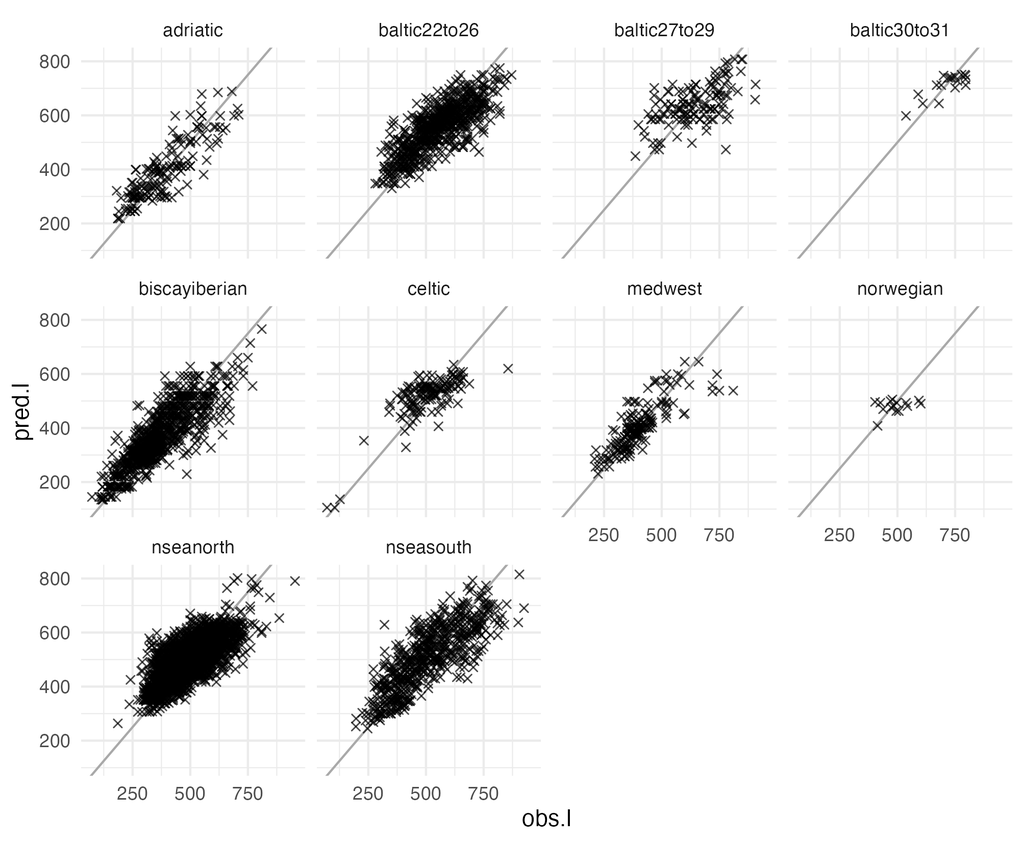

Figure 1: Observed and model predicted yellow eel length at age by eco-region.

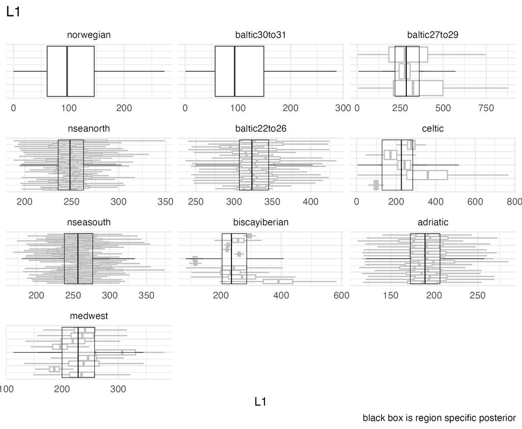

Figure 2: Posterior estimates of $L_1$ by region (black line) and basin (grey lines). Parameters are estimated for females (see covariate effect $b_{sL}$)

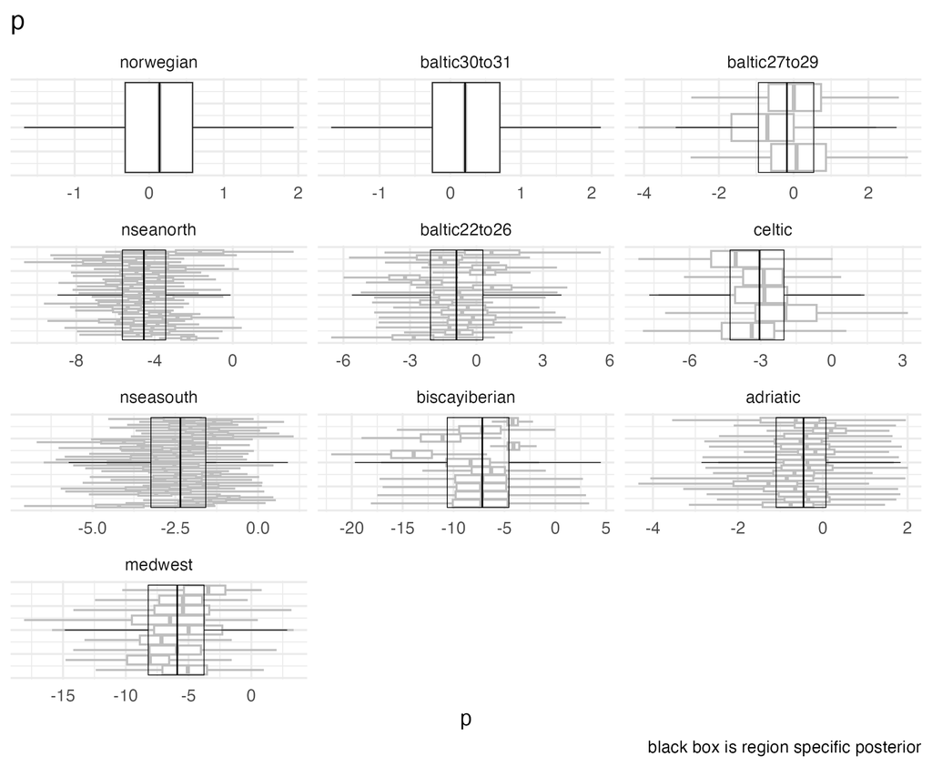

Figure 3: Posterior estimates of $p$ by region (black line) and basin (grey lines).

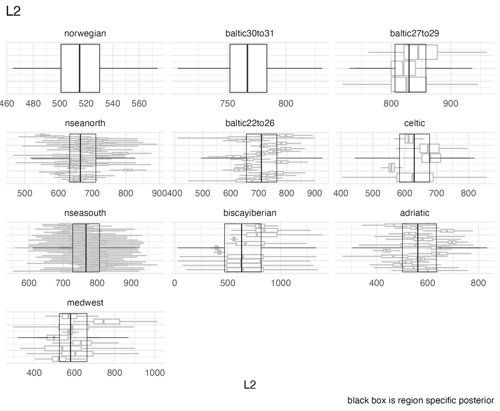

Figure 4: Posterior estimates of $L_2$ by region (black line) and basin (grey lines).

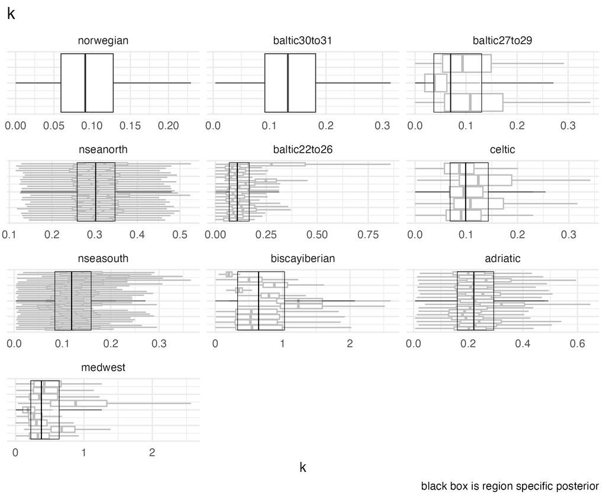

Figure 5: Posterior estimates of $k$ by region (black line) and basin (grey lines). Parameters are estimated for females (see covariate effect $b_{sk}$)

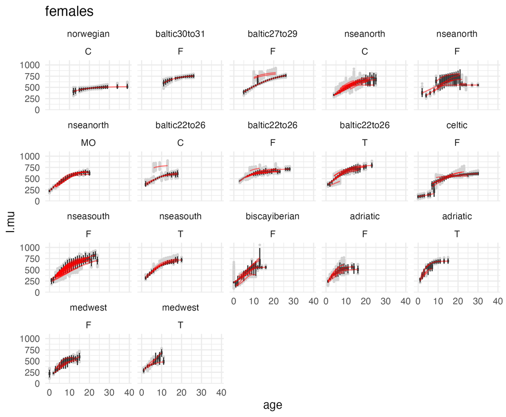

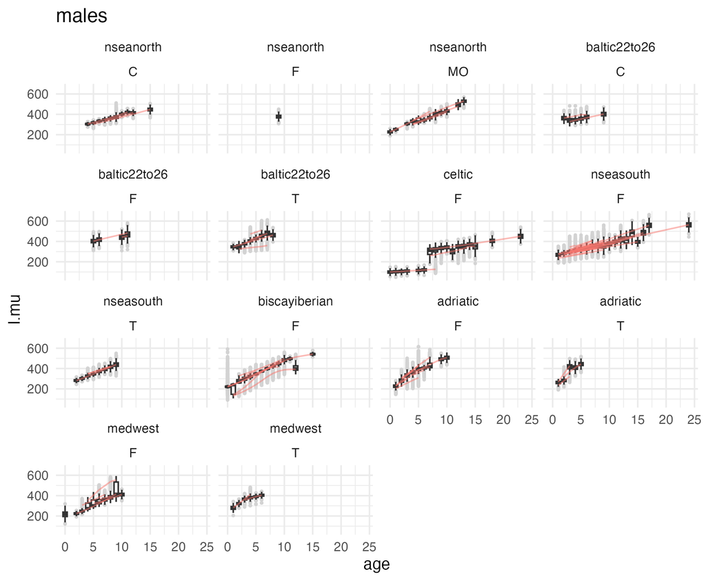

Figure 7: Predicted male yellow eel length at age ($\mu_{L_i}$). Boxes are region specific median estimates with interquartile range and outliers are in grey. The line shows basin specific growth curves.

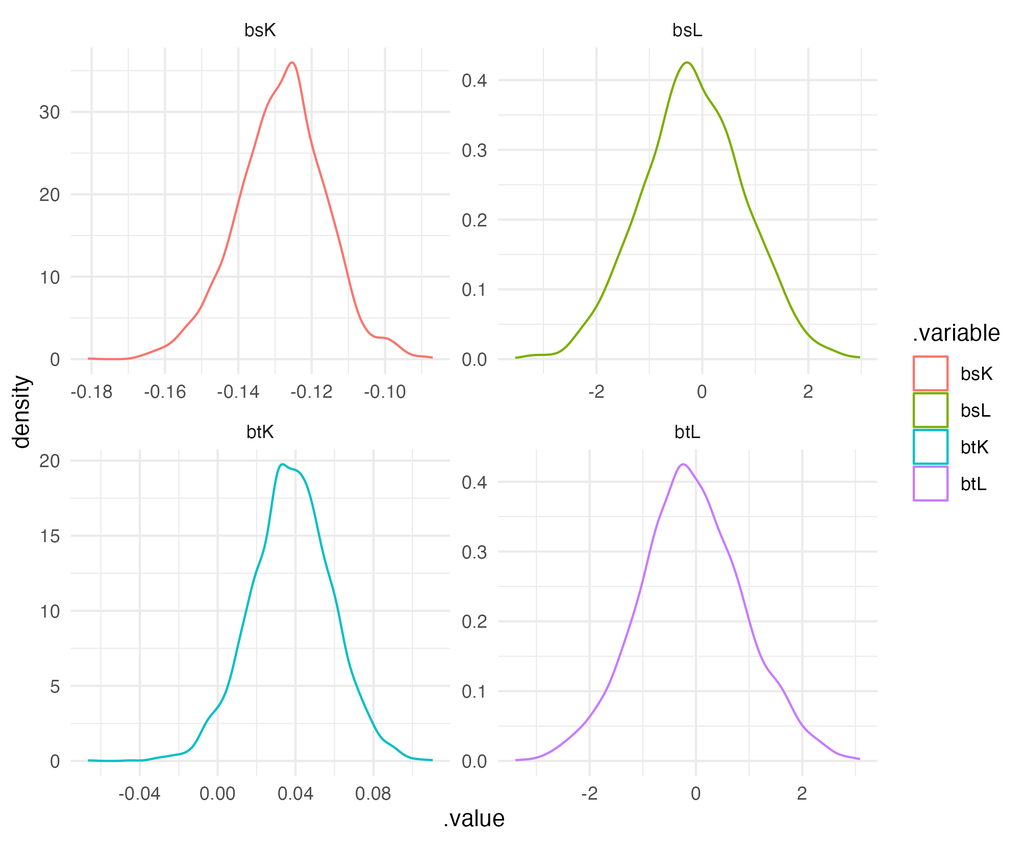

Figure 8: Posterior distributions of covariate parameters of the yellow eel length at age model.

### Spatiotemporal variation in length at silvering

We modeled body length at silvering using hierarchical lognormal regression accounting for differences among eco-regions and temporal variation across years. Covariate effects of sex and region specific temperature were included in the model.

#### Data

We used the data on silver eels from the WGEEL database (described in DIASPARA WP2.1 Data Inventory) from 1998 an onwards (earlier data was excluded to reduce number of estimated nodes without data). We retrieved information on region using the DIASPARA habitat database (DIASPARA WP3). After removing observations from the Norwegian sea (due to only three silver eels from this region), nine regions were represented in the data: Adriatic sea, Bay of Biscay / Iberian peninsula, Celtic sea, North sea north, North sea south, North sea UK, Baltic sea ICES subdivision 22 to 26, Baltic sea ICES subdivision 27 to 29 and Mediterranean west. The resulting data set contained 147 494 observations.

Region specific temperature information from the HydroSHEDS database (Lehner, Verdin, and Jarvis 2008) was retrieved using the the DIASPARA habitat database (DIASPARA WP3) and was z-score scaled before use in the model.

#### Model description

We used a lognormal likelihood for $length_i$ of individual $i$ (i = 1,,n_{obs}) to capture positive values and right‑skewed variability typical of growth data.

$L_i \sim \text{LogNormal}(\mu_{L_{[i]}}, \sigma)$

where $\mu_{L_i}$ is the expected log-length for individual $i$ and $\sigma$ is the residual standard deviation on the log scale. In turn, log-length is predicted by:

$\mu_{L_i} = \alpha_{j[i],year[i]} + b_{s,j}sex[i] + b_{t,j}T_{j[i]}$,

where $\alpha_{j,year}$ represents the intercept for region $j = 1,\dots,n_{j}$ in year $y$, $b_{s,j}$ is a region specific effect of sex, $b_t$ is the effect temperature in region $j$.

To account for temporal autocorrelation and spatial correlation, region specific intercepts were modeled as a multivariate random walk across years. Here, the intercepts in the first year were assigned a hierarchical prior to share information across regions,

$$\alpha_{j,1} \sim \text{Normal}(\mu_{\alpha,j},\, \sigma_{\alpha,j})$$
In subsequent years, the vector of intercepts follow a multivariate normal distribution

$$\boldsymbol{\alpha}_{i+1} \sim \text{MVN}(\boldsymbol{\alpha}_{i},\, \Sigma_\alpha),$$

where $\Sigma_\alpha$ is a covariance matrix describing correlation among regions. We used an LKJ prior for the corresponding correlation matrix $R_\alpha$ to estimate correlations among regions. The covariance matrix relates to the correlation matrix by

$$\Sigma_\alpha = D R_\alpha D,$$

where $D$ is a diagonal matrix of region specific standard deviations $\sigma_{\alpha,l}$.

Hyperpriors for region specific intercept and standard deviations were

$$\mu_{\alpha,j} \sim \text{Normal}(\mu_{sl},\, \sigma_{sl}),$$

$$\sigma_{\alpha,j} \sim \text{Gamma}(1.5,\, 1.5/\sigma_{sl}).$$

and we used a hierachical prior for a region specific covariate effect of sex,

$$b_{s,j} \sim \text{Normal}(\mu_{bs}, \sigma_{bs})$$

The hyperparameter values $\mu_{sl}, \sigma_{sl}, \mu_{bs}$ and $\sigma_{bs}$ are based on estimates of sex specific length at silvering in Durif, Dufour, and Elie (2005). The remaining parameters in the length at silvering model were assigned weakly informative priors (see Table 2).

Table 2: Prior distributions for parameters in the eel length at silvering model. (**Values are lognormal transformations of estimates in (2005)*.

[output not shown]

The model was implemented in NIMBLE, and posterior distributions of model parameters was estimated using Hamiltonian Monte Carlo sampling. Convergence was assessed by checking trace plots and Gelman–Rubin diagnostics (Gelman and Rubin 1992) (see model scripts and summary for details on model formulation and diagnostics).

#### Results

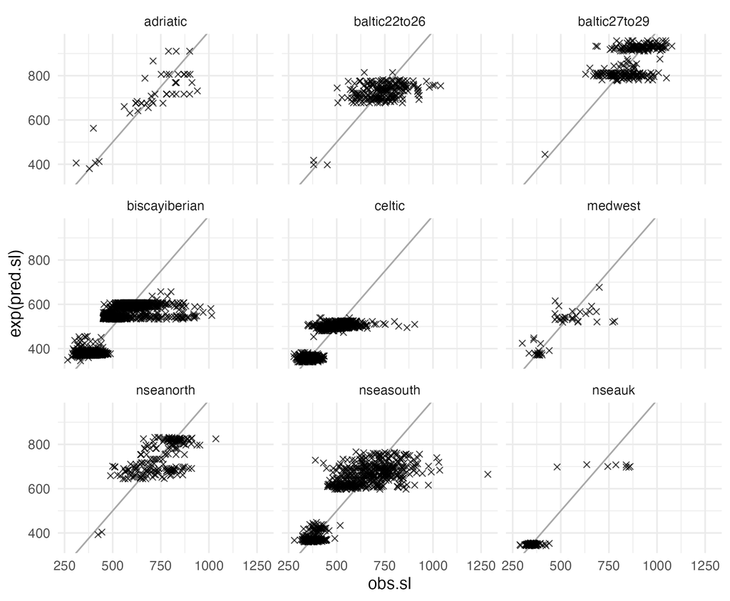

Figure 9: Observed and model predicted length at silvering by eco-region.

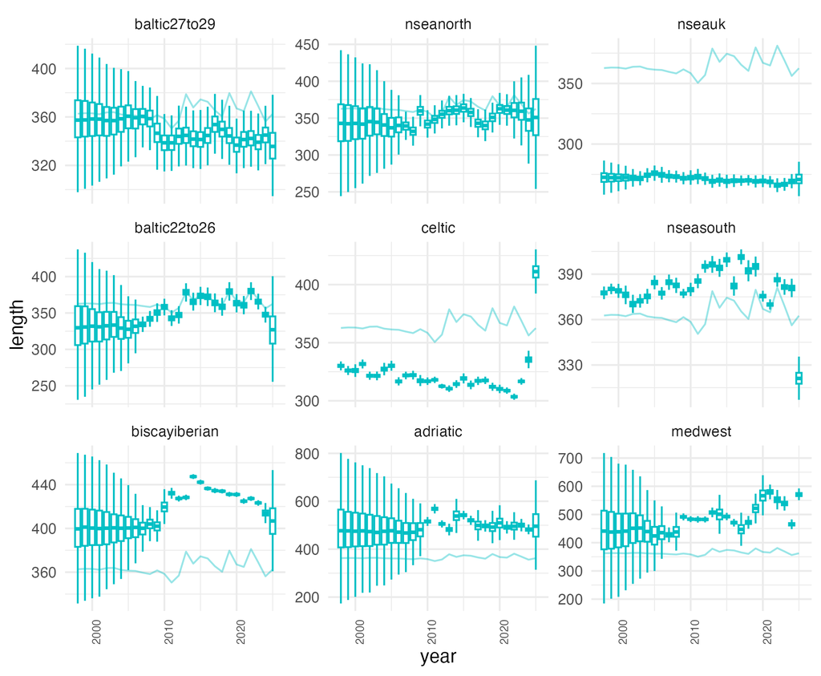

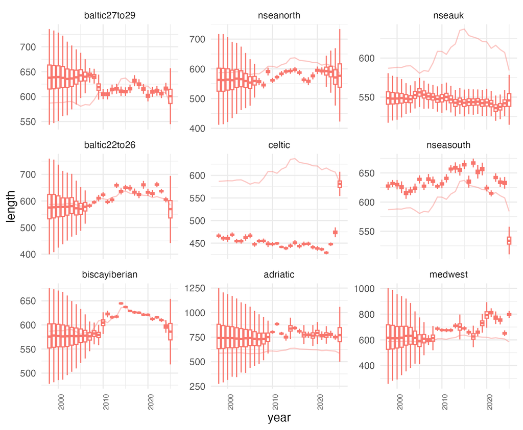

## Salmon

### Spatiotemporal variation in salmon length at age

We built a spatiotemporal model of individual body length as a function of age using a biphasic growth model. A biphasic growth model, separating life stages, is suitable for salmon as growth is strongly habitat dependent (Nater et al. 2018). The model predicts age dependent length increments of cohorts recursively using a linear function for the freshwater (juvenile) phase and the von Bertalanffy growth function for the sea phase.

The model predicts estimates growth for each sex, cohort and smolt age across spatial units and over time.

#### Data

We used data collected within the DIASPARA salmon data request on length data (total length in mm) on aged (in years) salmon individuals caught both in freshwater and at sea. The data included in the model comes from 12 spatial units: six in the Baltic sea (Assessment unit 1-5 and unknown (NA) assessment unit), the Swedish west coast, Brittany, lower Normandy, Adour, upper Normandy and the Irish west coast. We excluded non-aged individuals and individuals caught at sea and missing information of sex. This resulted in 79 559 individual observations for the model.

To account for seasonal variation in growth, a growth year ($age_g$) is consider as starting on May 1. Consequently, we assumed that all individuals are born on first of May and a growth year represents estimated age + 1 (e.g. $age_g$ of age 0 individuals equals 1).

#### Model descritpion

##### Biphasic process model

Expected increment in length at age was modeled recursively to capture changes in length $\mu_L$ across habitats and to predict growth rates for each year $y$. We estimated length increments for each spatial unit $j$, smolt age $a$, cohort $c$, sex $s$, and growth year $age_g$. For the freshwater, linear growth phase, expected length is predicted by

$$\mu_{L,j,a,c,s,age_g} = L_{b,j} + r_j$$
where $L_{b,j}$ is the length at birth and $r_j$ is juvenile growth rate in $mm/y$.

Growth in the sea phase is predicted by the Fabens (1965) version of the von Bertalanffy growth equation (with $\Delta t = 1$) which is suitable for modelling incremental data to predict expected length:

$$\mu_{L,j,a,c,s,age_g} = \mu_{L,j,a,c,s,age_g-1} + (L_{\infty,j,s} - \mu_{L,j,a,c,s,age_g-1})(1 - \exp(-k_{j,s,y}))$$
where $L_{\infty,j,s}$ is the spatial unit and sex-specific asymptotic length, $k_{j,s,y}$ is a year-specific von Bertalanffy growth coefficient where $y = c+age_g$. Smoltification at age $a$ delimits the two growth phases.

##### Observation models

We separated the observations by growth phase and used two observation models since the process model was built for fish carrying information on growth in both the age at smoltification and final age and for freshwater observations (parr and smolt), only the expected length predicted by linear growth is useful.

For salmon caught in their sea phase, observations i, length (total length in mm) was assumed to follow a normal distribution:

$L_{s,i} \sim \text{Normal}(\mu_{L_i,j[i],a[i],c[i],s[i],age_g[i]}, \sigma_{Ls})$

where $\mu_{L_i}$ is the expected length predicted by spatial unit (j), smolt age (a), cohort (c), sex (s), and growth year (age_g), and $\sigma_Ls$ is the residual observation error.

We used a normal likelihood also for the freshwater observations:

$L_{f,i} \sim \text{Normal}(mu_{Lj}, \sigma_{Lj})$

$\mu_{Lj} = L_{b,j[i]} + r_{j[i]}age_{g[i]}$

where $\sigma_{Lf}$ is the juvenile observation error.

##### Spatialtemporal process and priors

Parameters $L_{b,j}$, $r_j$ and $L_{\infty,j,s}$ were given estimates by spatial unit. The spatial unit specific estimates of the growth coefficient $k_{j,s,y}$ follows a multivariate random walk across years. The estimates in the first year were assigned a hierarchical prior to share information across regions:

$$k_{j,s,y=1} \sim \text{Normal}(\mu_{k,j}, \sigma_{k,j})$$
where $\mu_{k,j}$ and $\sigma_{k,j}$ are vectors of means and standard deviations by each spatial unit $j$. In years $y = 2, \dots, n_y$, the growth coefficient follow a multivariate normal distribution

$$\boldsymbol{k_{j,s,y}} \sim \text{MVN}(\boldsymbol{k_{j,s,y-1}},\, \Sigma_k),$$

where $\Sigma_k$ is a covariance matrix describing correlation among spatial units. We used an LKJ prior to estimate the corresponding correlation matrix $R_k$ of $\Sigma_k$. Here

$$\Sigma_k = D R_k D,$$

where $D$ is a diagonal matrix of region specific standard deviations in $\sigma_{k,j}$.

We used informative priors based on literature values (Fishbase Froese, R. and Pauly, D. (2025) and published studies) for $L_{\infty}, k,r$ and $L_b$ and weakly informative priors for the remaining parameters in the model (See table Table 3 for prior specifications).

Table 3: Prior distributions for parameters in the salmon length at age model. (**Values are estimated on log scale and are lognormal transformations of estimates from Fishbase (Froese, R. and Pauly, D. 2025)*.

| Parameter | Description | Prior distribution | Values |
| --- | --- | --- | --- |
| $\sigma_L$ | Sea length observation error SD | $\text{Exponential}(1/150)$ |  |
| $\sigma_{Lj}$ | Freshwater length observation error SD | $\text{Exponential}(1/20)$ |  |
| $L_{b,j}$ | Mean length at birth in $j$ | $\text{Uniform}(12, 20)$ | (Gilbey et al. 2009) |
| $r_j$ | Freshwater linear growth rate in $j$ | $\text{Normal}(\mu_r, 1)$ * | $\mu_r = 1.26$ ** |
| $L_{\infty,j,s}$ | Spatial unit and sex specific asymptotic length | $\text{Normal}(L_{\infty,\mu}, L_{\infty,sd})$ * | $L_{\infty,\mu} = 5.93$, $L_{\infty,sd} = 0.20$ ** |
| $k_{j,s, y=1}$ | Initial spatial unit- and sex specific mean growth coefficient | $\text{Normal}(k_{\mu}, 0.5)$ * | $k_{\mu} = -0.98$ ** |
| $\sigma_{k,j}$ | Spatial SD of growth coefficient variation | $\text{Lognormal}(\log(k_{\text{sd}}), 0.1)$ | $k_sd = 0.59$ |
| $\Sigma_p$ | Spatial covariance matrix for $k_{j,s,y}$ | $D,R_k,D$ |  |
| $R_k$ | Spatial correlation matrix for $k_{j,s,y}$ | $\text{LKJ}(\eta=2)$ |  |

The model was implemented in NIMBLE, and posterior distributions of model parameters was estimated using Hamiltonian Monte Carlo sampling. Convergence was assessed by checking trace plots and Gelman–Rubin diagnostics (Gelman and Rubin 1992) (see model scripts and summary for details on model formulation and diagnostics).

#### Results

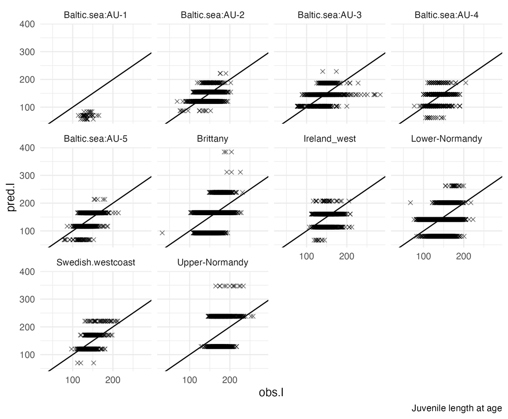

Figure 12: Observed and model predicted freshwater phase length at age by spatial unit.

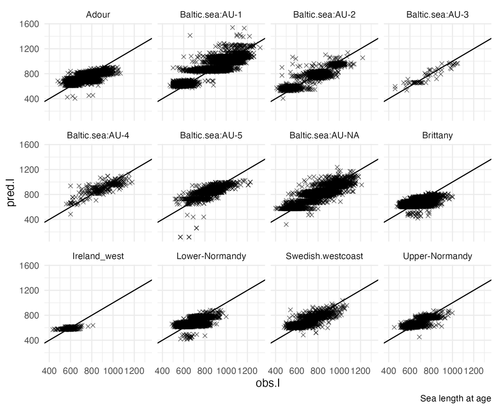

Figure 13: Observed and model predicted sea phase length at age by spatial unit.

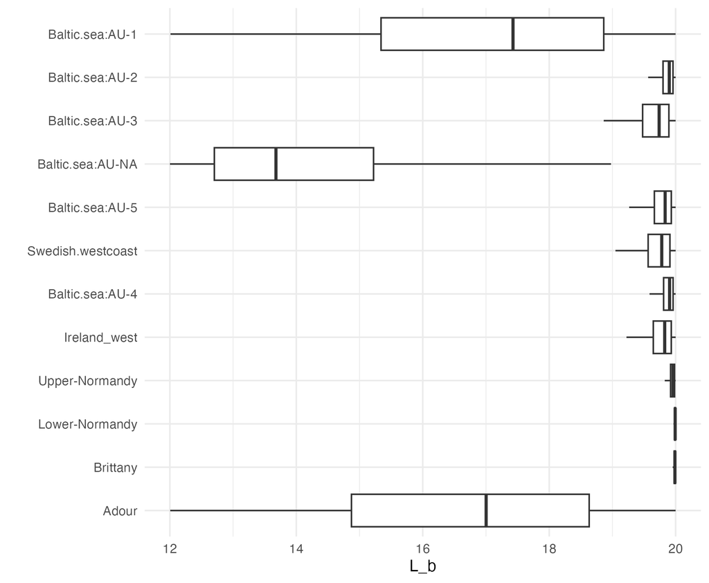

Figure 14: Salmon length at hatching ($L_b$) over spatial units. Regions are ordered by their mean laititude. Note that spatial units Adour and Baltic Sea AU:NA lack freshwater observation data.

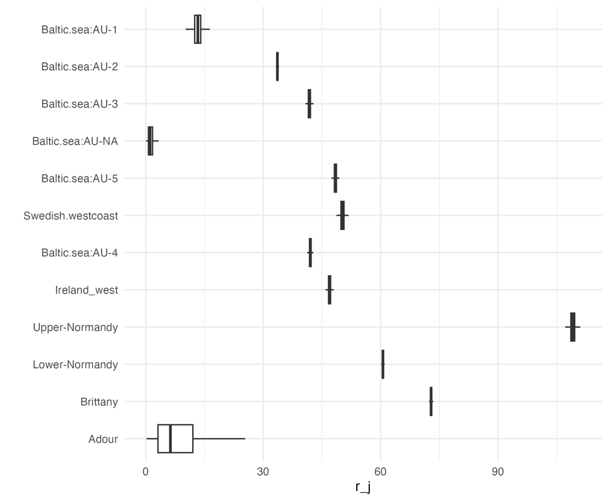

Figure 15: Salmon freshwater linear growth rate ($r$) over spatial units. Regions are ordered by their mean laititude. Note that spatial units Adour and Baltic Sea AU:NA are lack freshwater observation data.

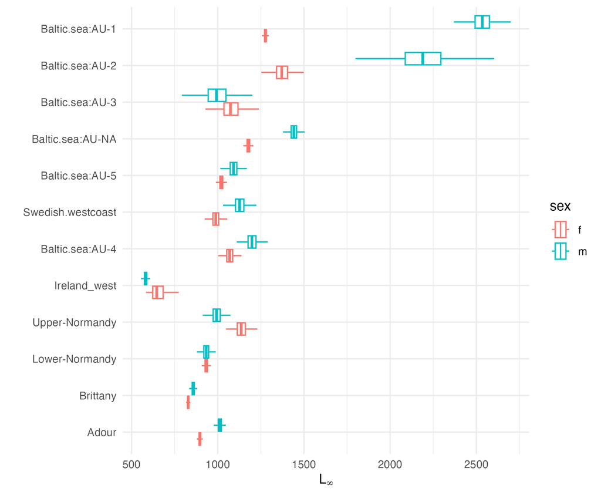

Figure 16: Salmon asymptotic length ($L_\infty$) over spatial units and by sex.

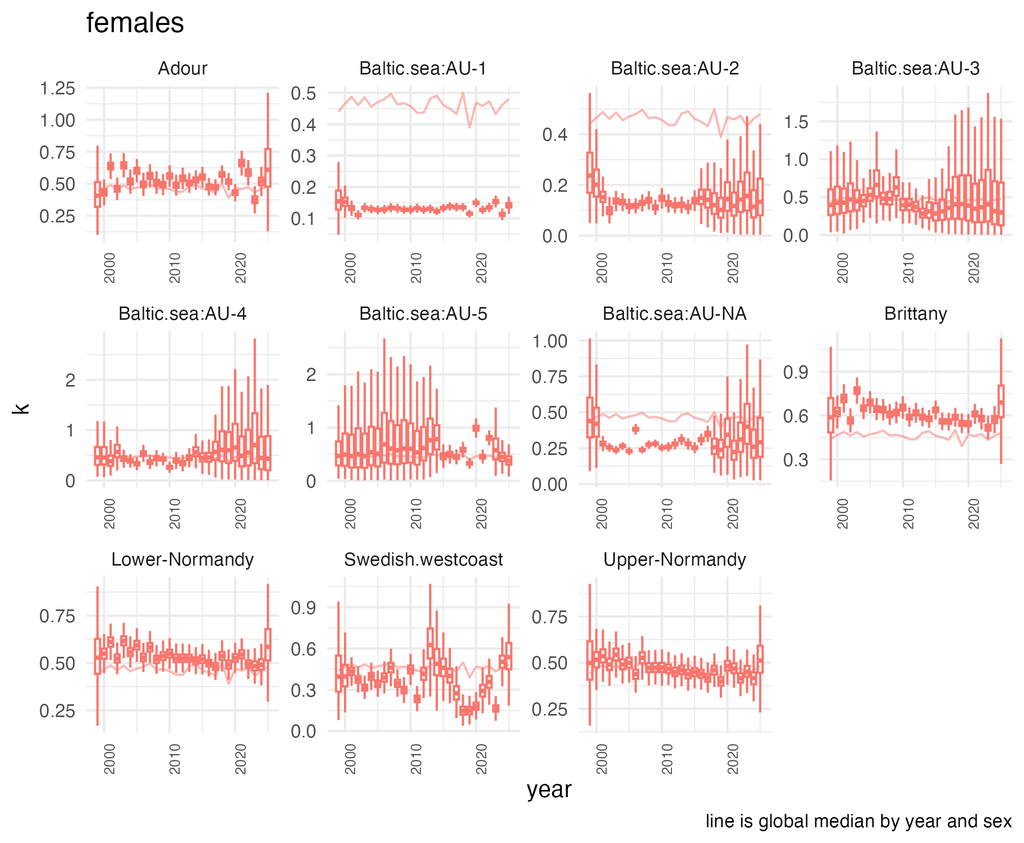

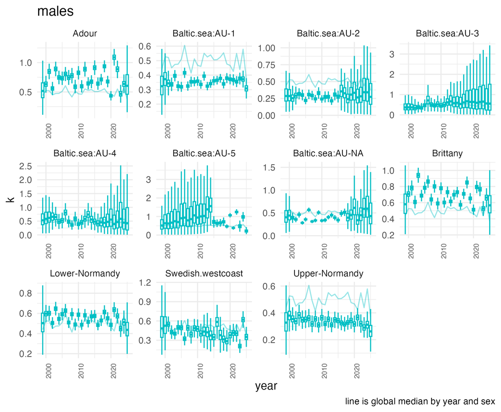

Figure 18: Salmon male growth coefficient ($k$) by spatial units over time.

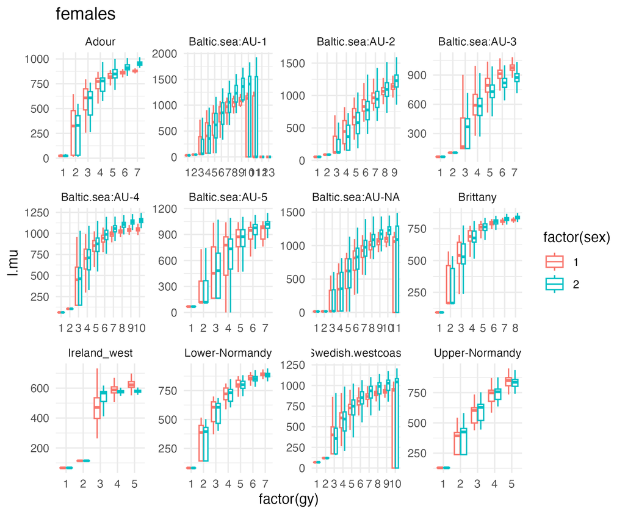

### Spatial variation in salmon fecundity

To describe spatial variation in fecundity, we developed a model of number of eggs per spawner given by length (fecundity at length). While e.g. age can be good predictors of fecundity (de Eyto et al. 2015), we used length as this was measured across all individuals in the data.

#### Data

The methodology for assessing number of eggs in salmon gonads vary between spatial units. Most importantly, the process of removing the eggs from the fish vary. In salmon hatchery breeding / rearing, the common method is to “strip” the salmon by hand by applying pressure to the abdomen of the spawning-ready females to expel the eggs. This leaves a varying amount of eggs left in the gonad resulting in uncertain counts. For scientific assessments, requiring more precise estimates of egg counts, stripping is either supplemented with removing the gonad (lethal method) and counting remaining eggs or all eggs are counted from the removed gonad (i.e. no stripping).

#### Model description

We assessed spatial variation in individual fecundity ($n.eggs$, egg count per spawner female) using a hierarchical negative binomial regression model to account for overdispersion.

$$n.eggs_i \sim \text{NegBin}(p_i, r)$$
where $r$ is the dispersion parameter and $p_i = r/(r+\mu_i)$. Expected fecundity of individual $i$ ($\mu_i$) was modeled as a log–linear function of individual body length:

$$log(\mu_i) = a_j + b_j \times \text{length.lc}_i$$
where $a_j$ and $b_j$ is intercept and slope of the length–fecundity relationship varying among spatial units $j = 1, \dots, n_{su}$ and $\text{length.lc}_i$ is mean centered log-length.

To share information across spatial units, intercepts ($a_j$) and slopes ($b_j$) were given hierarchical priors with hyperparameters specified for the group-level means ($\mu_a, \mu_b$) and standard deviations ($\sigma_b, \sigma_a$) (Table 4). Weakly informative priors were used for all parameters in the model (See table Table 4 for prior specifications).

The model was implemented in NIMBLE, and posterior distributions of model parameters was estimated using Hamiltonian Monte Carlo sampling. Convergence was assessed by checking trace plots and Gelman–Rubin diagnostics (Gelman and Rubin 1992) (see model scripts and summary for details on model formulation and diagnostics).

Table 4: Prior distributions for parameters in the salmon fecundity model.

| Parameter | Description | Prior distribution |
| --- | --- | --- |
| $\text{n.eggs}_i$ | Number of eggs for individual $i$ | $\text{NegBin}(p_i, r)$ |
| $r$ | Negative binomial dispersion parameter | $\text{Gamma}(1, 1)$ |
| $a_j$ | Spatial unit specific intercept | $\text{Normal}(\mu_a, \sigma_a)$ |
| $b_j$ | Spatial unit specific slope | $\text{Normal}(\mu_b, \sigma_b)$ |
| $\mu_a$ | Mean intercept across spatial units | $\text{Normal}(0, 1)$ |
| $\sigma_a$ | SD of intercepts across spatial units | $\text{Exponential}(0.5)$ |
| $\mu_b$ | Mean slope across spatial units | $\text{Normal}(1, 1)$ |
| $\sigma_b$ | SD of slopes across spatial units | $\text{Exponential}(0.5)$ |

#### Results

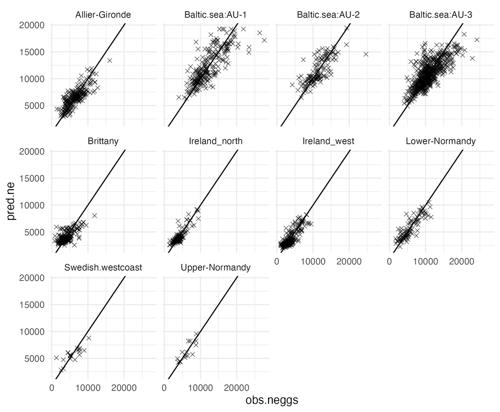

Figure 20: Observed and model predicted fecundity at length by spatial unit.

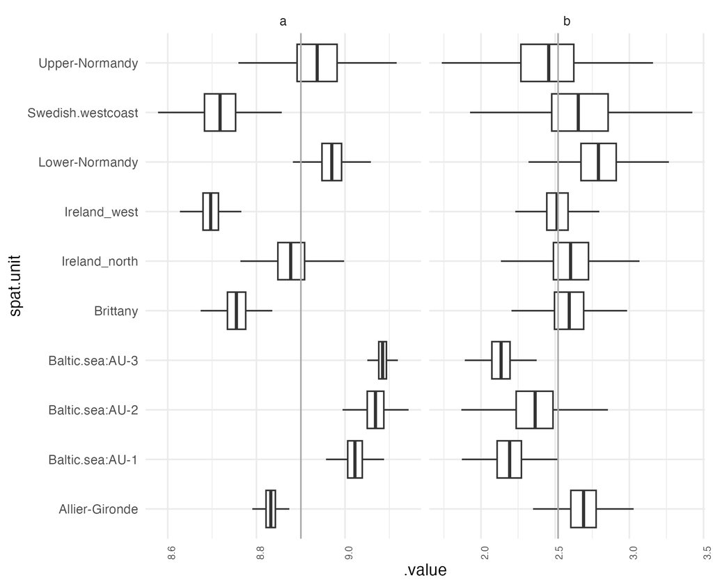

Figure 21: Estimates of $a$ and $b$ by spatial unit. Boxes shows the median and interquartile range, whiskers extend beyond that range and outliers are excluded. The grey line shows the overall median.

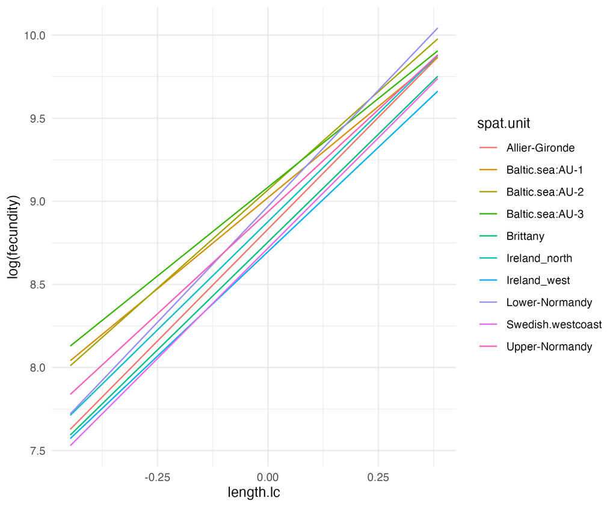

Figure 22: Length dependent fecundity by spatial unit.

## References

de Eyto, E., J. White, P. Boylan, B. Clarke, D. Cotter, D. Doherty, P. Gargan, et al. 2015. “The Fecundity of Wild Irish Atlantic Salmon Salmo Salar l. And Its Application for Stock Assessment Purposes.” *Fisheries Research* 164: 159–69. https://doi.org/https://doi.org/10.1016/j.fishres.2014.11.017.

Durif, C., S. Dufour, and P. Elie. 2005. “The Silvering Process of Anguilla Anguilla: A New Classification from the Yellow Resident to the Silver Migrating Stage.” *Journal of Fish Biology* 66 (4): 1025–43. https://doi.org/https://doi.org/10.1111/j.0022-1112.2005.00662.x.

Fabens, A. J. 1965. “Properties and Fitting of the von Bertalanffy Growth Curve.” *Growth* 29: 265–89.

Froese, R., and Pauly, D. 2025. “FishBase.” World Wide Web electronic publication. https://www.fishbase.org.

Gelman, Andrew, and Donald B. Rubin. 1992. “Inference from Iterative Simulation Using Multiple Sequences.” *Statistical Science* 7 (4): 457–72. https://doi.org/10.1214/ss/1177011136.

Gilbey, J., E. Cauwelier, C. S. Jones, A. Mclay, L. R. Noble, and E. Verspoor. 2009. “Size-Dependent Growth of Individual Atlantic Salmon Salmo Salar Alevins from Hatch to First Feeding.” *Journal of Fish Biology* 75 (10): 2820–31. https://doi.org/https://doi.org/10.1111/j.1095-8649.2009.02497.x.

Lehner, B., K. Verdin, and A. Jarvis. 2008. “New Global Hydrography Derived from Spaceborne Elevation Data.” *Eos, Transactions, American Geophysical Union* 89 (10): 93–94. https://doi.org/10.1029/2008EO100001.

Moll, Dorothee, Harald Asmus, Alexandra Blöcker, Uwe Böttcher, Jan Conradt, Leonie Färber, Nicole Funk, et al. 2024. “A Climate Vulnerability Assessment of the Fish Community in the Western Baltic Sea.” *Scientific Reports* 14: 16184. https://doi.org/10.1038/s41598-024-67029-2.

Nater, Chloé R., Atle Rustadbakken, Torbjørn Ergon, Øystein Langangen, S. Jannicke Moe, Yngvild Vindenes, Leif Asbjørn Vøllestad, and Per Aass. 2018. “Individual Heterogeneity and Early Life Conditions Shape Growth in a Freshwater Top Predator.” *Ecology* 99 (5): 1011–17. https://doi.org/https://doi.org/10.1002/ecy.2178.

PERRIER, CHARLES, RENÉ GUYOMARD, JEAN-LUC BAGLINIERE, and GUILLAUME EVANNO. 2011. “Determinants of Hierarchical Genetic Structure in Atlantic Salmon Populations: Environmental Factors Vs. Anthropogenic Influences.” *Molecular Ecology* 20 (20): 4231–45. https://doi.org/https://doi.org/10.1111/j.1365-294X.2011.05266.x.

Schnute, Jon. 1981. “A Versatile Growth Model with Statistically Stable Parameters.” *Canadian Journal of Fisheries and Aquatic Sciences* 38 (9): 1128–40. https://doi.org/10.1139/f81-153.

EU is not reponsible for the content of the project